# Data Challenge #1

Mario Saraiva - mhs2195

GR5069 - TOPICS IN APPLIED DATA SCIENCE FOR SOCIAL SCIENTISTS - Spring 2018

February 17, 2018

```r
##About this Project
# File-Name:      Data_Challenge_1_MarioSaraiva.Rmd
# Version:        R 3.4.1
# Date:           Feb 14, 2018
# Author:         MS
# Purpose:        Verify the lethality index with reported figures reported by
# the NY Times in 2016 that said: " `86.1% of dead civilians` who presumably
# participated in confrontations with federal armed forces were killed in events
# of "perfect lethality" where there were only dead and no wounded. [...] Mexico
# has the terrible situation of having `lethality indices of 2.6`. The lethality
# index of the Federal Police is `2.6 dead for every wounded`, the Navy's reaches
# 17.3 dead for every wounded, and the Army's is 9.1 dead for every wounded."
# (Ahmed & Schmitt, 2016)
# Input Files:    1. AllViolenceData_171220.csv
# Output Files:   Data_Challenge_1_MarioSaraiva.html
# Data Output:    None
# Previous files: None
# Dependencies:   None
# Required by:    None
# Status:         IN PROGRESS
# Machine:        Mac laptop
```

```r
# Throughout this document the following items were addressed:
#
# 1. Can you replicate the 86.1% number? the overall lethality ratio? the ratios for the Federal Police, Navy and Army?
#
#     a. Provide a visualization that presents this information neatly.
#
#     b. Please show the exact computations you used to calculate them.
#
#
# 2. Is this the right metric to look at? Why or why not?
#
# 3. What is the "lethality index" showing explicitly? What is it not showing? What is the definition assuming?
#
# 4. With the same available data, can you think of an alternative way to capture the same construct? Is it "better"?
#
# 5. What additional information would you need to better understand the data?
#
# 6. What additional information could help you better capture the construct behind the "lethality index"
```

## Lethality Rate in Mexico

Stats given in the NY Times article:

1. `86.1% of dead civilians` in confrontations with **federal armed forces**.
2. `Mexico's lethality indices of 2.6`
3. `2.6 dead for every wounded` ratio for the federal POLICE.
4. `17.3 dead for every wounded` ratio for the NAVY.
5. `9.1 dead for every wounded` ratio for the ARMY.

The NY Times article did not discuss how these numbers were calculated. I explored different ways they could have calculated to arrive at these numbers. To no one’s surprise, my results were different than the NY times results.

```r
#The proportion for the aggregate civilians lethality rate was the following

dta_gov_nongov <- dta %>%
  mutate(armforces_death = navy_dead + military_dead + federal_police_dead + state_police_dead + municipal_police_dead + ministerial_police_dead,
         armforces_wounded = navy_wounded + military_wounded + federal_police_wounded + state_police_wounded + municipal_police_wounded + ministerial_police_wounded,
         nonfed_wounded = civilian_wounded + organized_crime_wounded + afi_wounded + public_prosecutor_wounded,
         nonfed_dead = civilian_dead + organized_crime_dead + afi_dead + public_prosecutor_dead)
```

```r
#Presence of Armed forces and the impact on civilians.

##The following will count the total number of dead non-gov subjects given the presence of Armed Forces (A.F.)

indexes <- dta_gov_nongov %>%
  filter(armforces_wounded != 0 | armforces_death != 0 ) %>% #to make sure the armed forces were involved.
  summarize(count = sum(nonfed_dead))
colnames(indexes) <- "All.Non.AF_dead|A.F."
#The following will count the total number of wounded non-gov subjects given the presence of Armed Forces

indexes$All.NonAF.wound <- as.numeric(dta_gov_nongov %>%
  filter(armforces_wounded != 0 | armforces_death != 0 ) %>%
  summarize(count = sum(nonfed_wounded)))
#colnames(indexes$All.NonAF.wound) <- "All.Non.AF_wounded|A.F."

indexes$All.index <- as.numeric(indexes$`All.Non.AF_dead|A.F.` / indexes$All.NonAF.wound)
#colnames(indexes$All.index) <- "Armed Forces Lethality index "

count_all_total <- as.numeric(dta_gov_nongov %>%
   summarize(count = sum(armforces_wounded)))

indexes$All.Prop <- as.numeric(indexes$`All.Non.AF_dead|A.F.`/count_all_total)
#colnames(indexes$All.Prop) <- "non AF dead / AF dead"
```

```r
#Perfect Lethality cases
indexes$Perfect.L.dead <- as.numeric(dta_gov_nongov %>%
     filter(perfect_lethality != 0 & civilian_dead != 0) %>%
   summarize(count = sum(nonfed_dead)))

indexes$Perfect.L..Index <- as.numeric(indexes$Perfect.L.dead / (indexes$`All.Non.AF_dead|A.F.` + indexes$All.NonAF.wound))
```

```r
#Lethality ratios.

##Similarly, this section will calculate the 'lethality index' (Num. of civilians dead / num. of civilians wounded) given the participation of each armed force in the violent. I also calculate the proportion of civilians that died given the number of armed force officers that die, (Total Num. deaths non-armed forces) / (Total Num. deaths armed forces).

###This index has a clear shortcoming for it does not consider any armed forces officers that were dead or wounded during the violent event. This lethality index cannot be used to assess brutality of armed forces.

#Federal Police
##1 Aggregate for non A.F.
indexes$FP.nonAF.dead <- as.numeric(dta_gov_nongov %>%
   filter(federal_police_dead != 0 | federal_police_wounded != 0) %>%
   summarize(count = sum(nonfed_dead)))
##2
indexes$FP.nonAF.wounded <- as.numeric(dta_gov_nongov %>%
   filter(federal_police_dead != 0 | federal_police_wounded != 0) %>%
   summarize(count = sum(nonfed_wounded)))
##3
indexes$FP.nonAF.Index <- as.numeric(indexes$FP.nonAF.dead / (indexes$FP.nonAF.dead + indexes$FP.nonAF.wounded))
#colnames(indexes$FP.Index) <- "Lethality index | Federal Police "

##4 - Aggregates for Federal Police officers
indexes$FP.only.dead <- as.numeric(dta_gov_nongov %>%
  filter(federal_police_dead != 0 | federal_police_wounded != 0) %>%
   summarize(count = sum(federal_police_dead)))
##5
indexes$FP.only.wounded <- as.numeric(dta_gov_nongov %>%
  filter(federal_police_dead != 0 | federal_police_wounded != 0) %>%
   summarize(count = sum(federal_police_wounded)) )
##6
indexes$FP.only.Index <- as.numeric(indexes$FP.only.dead / (indexes$`All.Non.AF_dead|A.F.` + indexes$All.NonAF.wound) )
#colnames(indexes$FP.only.Index) <- "FP only dead/wounded "

##7 Ratio of total non AF dead / total FP dead
indexes$FP.prop.of.dead <- as.numeric(indexes$`All.Non.AF_dead|A.F.` / indexes$FP.only.wounded)

display_index <- t(format(round(indexes, 2), nsmall = 2))
display_index <- as.data.frame(display_index)
#colnames(display_index)[1] <- "Results"
```

```r
#Navy
##1 Aggregate for non A.F. | Navy presence
indexes$NV.nonAF.dead <- as.numeric(dta_gov_nongov %>%
   filter(navy_dead != 0 | navy_wounded != 0) %>%
   summarize(count = sum(nonfed_dead)))
##2
indexes$NV.nonAF.wounded <- as.numeric(dta_gov_nongov %>%
    filter(navy_dead != 0 | navy_wounded != 0) %>%
   summarize(count = sum(nonfed_wounded)))
##3
indexes$NV.nonAF.Index <- as.numeric(indexes$NV.nonAF.dead / (indexes$NV.nonAF.dead + indexes$NV.nonAF.wounded))
#colnames(indexes$FP.Index) <- "Lethality index | Navy "

##4 - Aggregates for Navy officers
indexes$NV.only.dead <- as.numeric(dta_gov_nongov %>%
  filter(navy_dead != 0 | navy_wounded != 0) %>%
   summarize(count = sum(navy_dead)))
##5
indexes$NV.only.wounded <- as.numeric(dta_gov_nongov %>%
  filter(navy_dead != 0 | navy_wounded != 0) %>%
   summarize(count = sum(navy_wounded)) )
##6
indexes$NV.only.Index <- as.numeric(indexes$NV.only.dead / (indexes$`All.Non.AF_dead|A.F.` + indexes$All.NonAF.wound))
#colnames(indexes$FP.only.Index) <- "FP only dead/wounded "

##7 Ratio of total non AF dead / total NV dead
indexes$NV.prop.of.dead <- as.numeric(indexes$`All.Non.AF_dead|A.F.` / indexes$NV.only.wounded)

#Army
##No data on a number of army officers wounded or killed.

#display_index <- t(format(round(indexes, 2), nsmall = 2))
#colnames(display_index)[1] <- "Results"
```

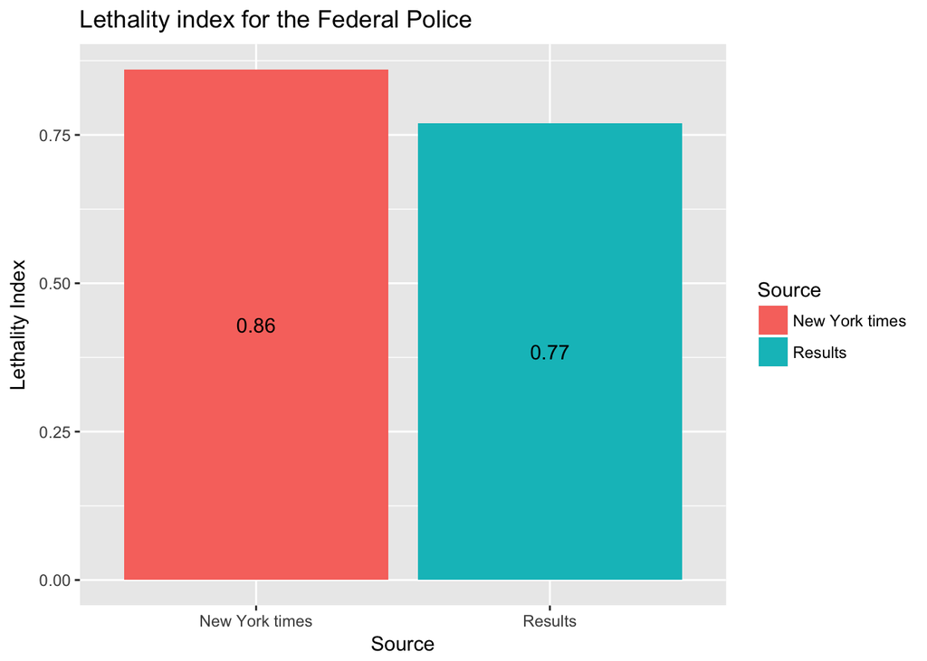

```r
nytimes <- 0.86
nytimes <- as.data.frame(nytimes)
nytimes$All.index <- 2.6
nytimes$FP.prop.dead <- 2.6
nytimes$NV.prop.dead <- 17.3
nytimes$Army.prop.dead <- 9.1

compare_indexes <- rbind(nytimes, c(indexes$FP.nonAF.Index, indexes$All.index, indexes$FP.prop.of.dead, indexes$NV.prop.of.dead, "NA"))
row.names(compare_indexes)[1] <- "New York times"
row.names(compare_indexes)[2] <- "Results"
compare_indexes$Source <- c("New York times", "Results")

compare_indexes$nytimes <- x2(compare_indexes$nytimes)

ggplot(compare_indexes) +
  geom_col(aes(Source, nytimes, fill = Source)) +
  ggtitle("Lethality index for the Federal Police") +
  labs(x = "Source", y = "Lethality Index") +
  geom_text(aes(Source, nytimes, label = nytimes), position = position_stack(vjust = 0.5))
```

## Discussion of Alertnative Calculations

Using the data available, I defined the lethality index can be defined as the ratio of the total number of civillians<sup>1</sup> dead given the presence of the armed forces<sup>2</sup> over the total number of civilians wounded given the presence of the armed forces. $\frac{ Num. \space of \space dead \space}{Num.\space of \space wounded\space}$ per confrontation or event. But this is confusing. For example, the overall lethality of government armed forces should be:

$$\frac{ Total \space Num. \space of \space non \space Armed\space Forces \space subjects \space dead \space | \space Armed \space Forces \space presence \space}{Total \space Num. \space of \space non \space Armed\space Forces \space subjects \space wounded\space | \space Armed \space Forces \space presence}$$
.

So given the presence of at least one government agency what is the proportion of dead and wounded people during the violent event that is not considered part of the armed forces? Confrontations vary a lot and are complex. For instance, battling in the sea is very different than on the ground, so many wounded in the sea does not have the same implications as wounded in land confrontations. Therefore, we should not over-stretch this ratio as an indicator of the brutality of federal armed forces. This ratio also does not address brutality of armed forces given confrontation nor does it take into account the guns used; 100 wounded using a heavy automatic weaponry is not the same as 100 wounded with a knife or physical aggression.

Alternative calculations measures what happened given the presence of a certain group (e.g. Federal Police) engaging in a confrontation. In other words, it measures the ratio of Federal Police officers engaged in a confrontation that died in comparison to other officers that were wounded. Then we can compare this ratio for Federal Police and Civilians. Although, that still does not shows us much.

### Computations

I developed alternatives attempting to overcome the limitations imposed by the data. These can be seen in my calculations.

## Results

#### Data visualizations

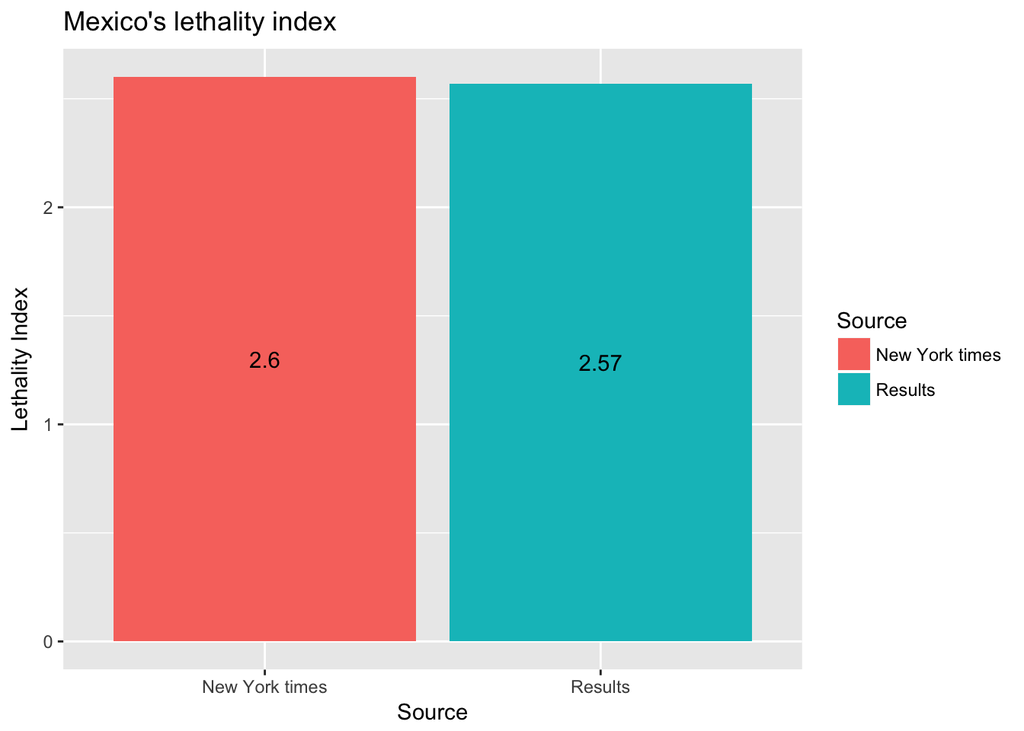

```r
compare_indexes$All.index <- x2(compare_indexes$All.index)
compare_indexes$FP.prop.dead <- x2(compare_indexes$FP.prop.dead)
compare_indexes$NV.prop.dead <- x2(compare_indexes$NV.prop.dead)
compare_indexes$Army.prop.dead <- x2(compare_indexes$Army.prop.dead)
ggplot(compare_indexes) +
  geom_col(aes(Source, All.index, fill = Source)) +
  ggtitle("Mexico's lethality index") +
  labs(x = "Source", y = "Lethality Index") +
  geom_text(aes(Source, All.index, label = All.index), position = position_stack(vjust = 0.5))
```

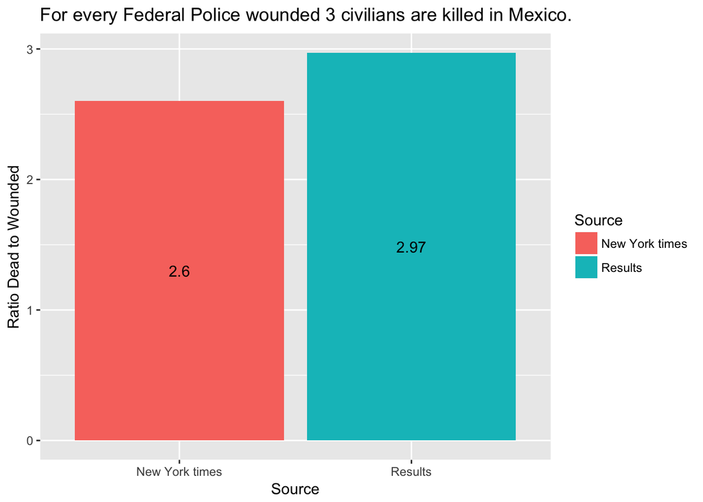

```r
ggplot(compare_indexes) +
  geom_col(aes(Source, FP.prop.dead, fill = Source)) +
  ggtitle("For every Federal Police wounded 3 civilians are killed in Mexico.") +
  labs(x = "Source", y = "Ratio Dead to Wounded") +
  geom_text(aes(Source, FP.prop.dead, label = FP.prop.dead), position = position_stack(vjust = 0.5))
```

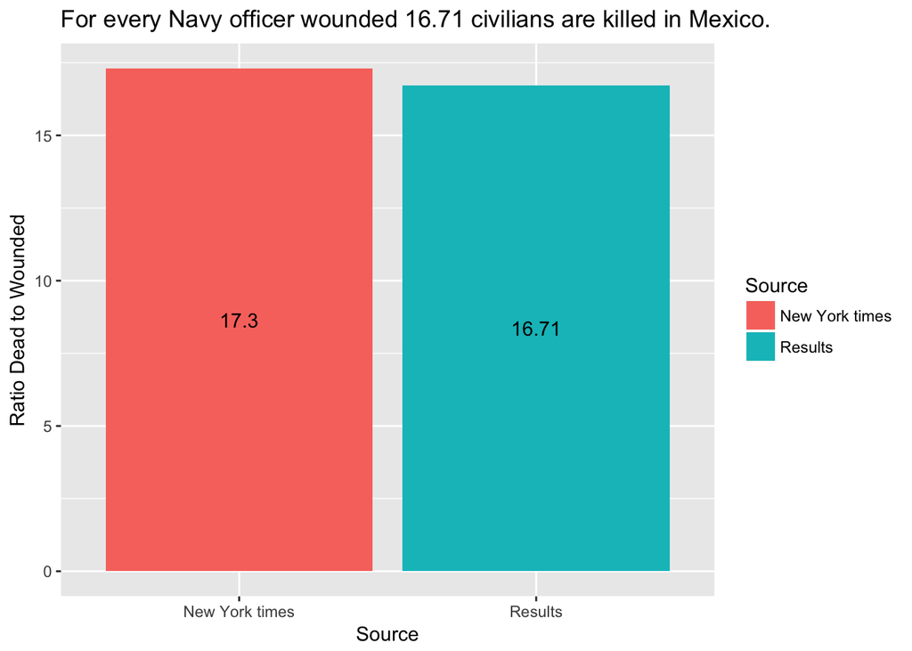

```r
ggplot(compare_indexes) +
  geom_col(aes(Source, NV.prop.dead, fill = Source)) +
  ggtitle("For every Navy officer wounded 16.71 civilians are killed in Mexico.") +
  labs(x = "Source", y = "Ratio Dead to Wounded") +
  geom_text(aes(Source, NV.prop.dead, label = NV.prop.dead), position = position_stack(vjust = 0.5))
```

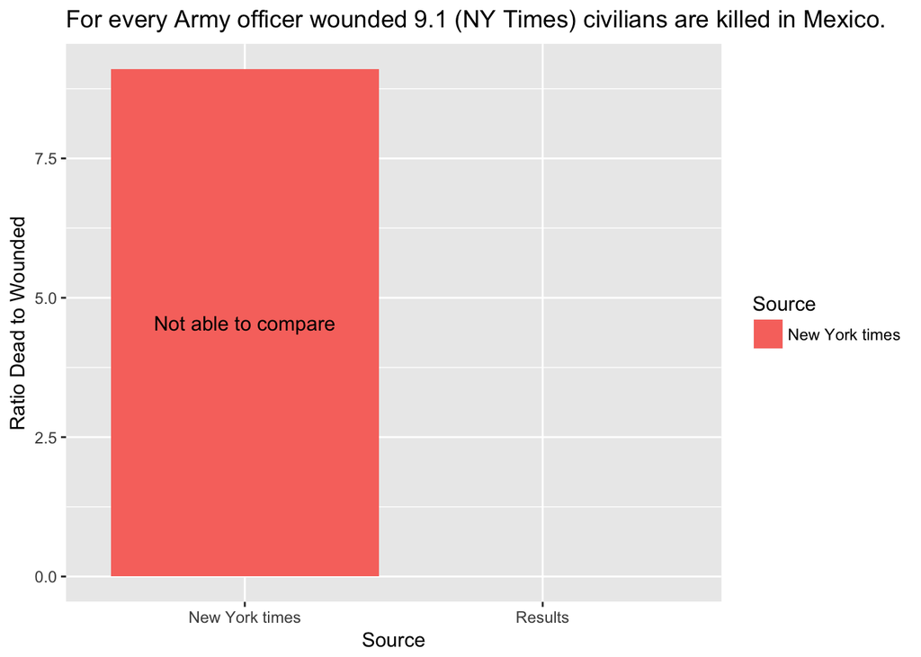

```r
ggplot(compare_indexes) +
  geom_col(aes(Source, Army.prop.dead, fill = Source)) +
  ggtitle("For every Army officer wounded 9.1 (NY Times) civilians are killed in Mexico.") +
  labs(x = "Source", y = "Ratio Dead to Wounded") +
  geom_text(aes(Source, Army.prop.dead, label = "Not able to compare"), position = position_stack(vjust = 0.5))
```

```r
# ggplot(df_rates) +
#    geom_col(aes(x = V2, y = V1, fill = V2)) +
#    labs(x = "Type of people", y = "Proportion") +
#    ggtitle("Proportion of Lethality (Num. deaths | wounded = 0) / (Total deaths) by people type")
#     ggsave(file = "plot1.png")
```

#### Summary Table

```r
indexes$results <- "results"
display_index <- dcast(melt(indexes, id.vars = "results"), variable ~ results)
display_index$results <-  x2(display_index$results)
```

[output not shown]

### Discussion about the Lethality Index

There were some significant issues when trying to calculate the ratios:

| Variable | Count of missing values |
| --- | --- |
| state | 20 |
| state_abbr | 20 |
| municipality | 20 |
| organized_crime_lethality | 19744 |
| army_lethality | 31463 |
| navy_lethality | 33787 |
| federal_police_lethality | 32680 |
| organized_crime_NewIndex | 19744 |
| army_NewIndex | 31463 |
| navy_NewIndex | 33787 |

## Conclusion: Improving the index

*Why killed-to-wounded ratios don’t measure lethality*

The lack of information on the total number of participants in each armed engagement is not clear. In other words, the denominator is unknown and “it is therefore very hard to estimate dead/wounded rates per event. It is important to make a distinction between the combat efficiency of armed forces - one index could be # of shots on target/shots fired and the brutality of the armed forces. It is very difficult to measure the”brutality" of, for example, a federal police officer for it is difficult to get accurate data on the number of wounded and dead and attribute the blame to the officer per se.

García-Ponce & Lajous (2016) drives the point home when they explain that “although the use of killed-to-wounded ratios has been suggested as an effective metric to track specific massacres (Coupland and Meddings, 1999), it is a statistic more frequently used to analyze medical attention during armed conflicts than to measure combat efficiency, the severity of civil war, or the use of force.”

Furthermore, the data does not allow us to understand the context of the confrontation, for example, we are unsure how many people were involved or the type of weapons used. The calculations measure the consequences for a certain group (e.g. Federal Police) of engaging in a confrontation event. In other words, it measures the ratio of Federal Police officers engaged in a confrontation that died in comparison to other officers that were wounded. Since violent events can have the cooperation of multiple armed force agencies, to identify if an agency was involved in the violent event we set ( $Federal\space Police \space wounded \space \space != 0$ ). So it becomes hard to say who killed/wounded who.

Lastly, I believe that to get a comprehensive picture on the brutality issue, there have to be qualitative assessments in order to capture the context of different conflicts. This is also very difficult given the high risk of violent conflicts, so most observers belong to either the armed forces or criminal organizations, and civilians are usually not comfortable to accurately report on what they saw as they fear any potential backlash. It is possible that, if the violent event was caught on video, to use the recorded images to make better assessments of the brutality and combat efficiency of the armed forces in Mexico.

### Footnotes

<sup>1</sup> Civilians, in this case, are all that are not part of the Armed Forces, so it includes the organized crime and government employees in other roles.

<sup>2</sup> Armed forces include all government agencies used to keep the law and order such as the Federal Police, the Army, the Navy, among others.

### References

García-Ponce, O., & Lajous, A. (2016, October 21). Challenges of Measuring an Armed Group’s Lethality: Insights from the Mexican Drug War. Retrieved February 16, 2018, from https://politicalviolenceataglance.org/2016/10/21/challenges-of-measuring-an-armed-groups-lethality-insights-from-the-mexican-drug-war/